# Solutions Homework 6

Author

Affiliation

University of Colorado Denver

# Solutions HW 6: NOT Collected

# Loading Data and Required Packages

Run the code cells below to load required packages. We will work with the `UN11` data frame from the `alr4` package.

```r
# load required packages
library(tidyverse)
library(alr4)
library(effects)
data(UN11, package = "alr4")
```

```r
glimpse(UN11)
```

[output not shown]

## Introduction

- `region`: region of the world
- `group`: a factor with levels `oecd` for countries that are members of the OECD, the Organization for Economic Co-operation and Development, as of May 2012, `africa` for countries on the African continent, and `other` for all other countries. No OECD countries are located in Africa.
- `fertility`: number of children per woman
- `ppgdp`: per capita gross domestic product in US dollars
- `lifeExpF`: female life expectancy, in years
- `pctUrban`: percent urban

We will consider the relationship between the response `log(fertility)` and several of the other variables in the data set.

# Question 1

Fit a linear model regressing the response `log(fertility)` on the predictor `pctUrban`. Print the estimated coefficients of the model.

## Solution to Question 1

```r
lmod <- lm(log(fertility) ~ pctUrban, data = UN11)
summary(lmod)
```

```
Call:
lm(formula = log(fertility) ~ pctUrban, data = UN11)

Residuals:
     Min       1Q   Median       3Q      Max
-0.87723 -0.31862  0.00894  0.29466  0.73472

Coefficients:
             Estimate Std. Error t value Pr(>|t|)
(Intercept)  1.500963   0.071397  21.023  < 2e-16 ***
pctUrban    -0.010163   0.001143  -8.892 3.86e-16 ***
---
Signif. codes:  0 '***' 0.001 '**' 0.01 '*' 0.05 '.' 0.1 ' ' 1

Residual standard error: 0.3768 on 197 degrees of freedom
Multiple R-squared:  0.2864,    Adjusted R-squared:  0.2828
F-statistic: 79.06 on 1 and 197 DF,  p-value: 3.858e-16
```

# Question 2

What is the equation for the fitted model?

## Solution to Question 2

$$\widehat{E}(\log(\mathtt{fertility})|\mathtt{pctUrban}) = 1.5 - 0.01 \mathtt{pctUrban}$$

# Question 3

Interpret the estimated coefficient for `pctUrban` in a straightforward sentence in the context of this example.

## Solution to Question 3

The number of children per birth parent is decaying at a continuous exponential rate of 1% for each 1% increase in the percentage of the population that lives in urban regions.

For members of the United Nations, a 1% increase in the percentage of the population living in Urban regions is associated with an expected decrease in the number of children per birth parent by about 1%.

# Question 4

Use the fitted model to construct an effect plot for `pctUrban` on `fertility` (on the original scale for `fertility`). Note you will need to modify the `axes` argument of the `plot` function.

**Tip**

The `effects` package has a vignette that may be helpful, it may be accessed by running `vignette("predictor-effects-gallery", package = "effects")` in the R console.

## Solution to Question 4

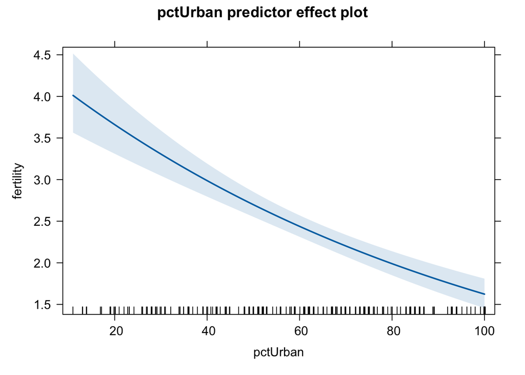

```r
plot(predictorEffect("pctUrban", lmod),
     axes=list(y=list(transform=exp, lab="fertility")))
```

# Question 5

Interpret the effects plot from Question 4.

## Solution to Question 5

Overall, as the percentage of the urban population increases, the average number of children a woman has tends to decrease. Have the effect seems to be weaker as percentage of the urban population increases.

# Question 6

Fit the linear model regressing `log(fertility)` on both `log(ppgdp)` and `lifeExpF`. Print the results to the R Console. Use this fitted model to also answer Questions 7-10.

## Solution to Question 6

```r
lmod2 <- lm(log(fertility) ~ log(ppgdp) + lifeExpF, data = UN11)
summary(lmod2)
```

```
Call:
lm(formula = log(fertility) ~ log(ppgdp) + lifeExpF, data = UN11)

Residuals:
     Min       1Q   Median       3Q      Max
-0.61778 -0.16891  0.03731  0.17591  0.61072

Coefficients:
            Estimate Std. Error t value Pr(>|t|)
(Intercept)  3.50736    0.12707  27.601  < 2e-16 ***
log(ppgdp)  -0.06544    0.01781  -3.675 0.000307 ***
lifeExpF    -0.02824    0.00274 -10.306  < 2e-16 ***
---
Signif. codes:  0 '***' 0.001 '**' 0.01 '*' 0.05 '.' 0.1 ' ' 1

Residual standard error: 0.248 on 196 degrees of freedom
Multiple R-squared:  0.6926,    Adjusted R-squared:  0.6894
F-statistic: 220.8 on 2 and 196 DF,  p-value: < 2.2e-16
```

# Question 7

What is the equation for the fitted model from the previous Question?

## Solution to Question 7

$$\widehat{E}(\log(\mathtt{fertility})|\mathtt{ppgdp}, \mathtt{lifeExpF}) = 3.5 - 0.065 \log(\mathtt{ppgdp}) - 0.03 \mathtt{lifeExpF}$$

# Question 8

Mathematically, if we increase `ppgdp` by 25%, what is the expected decrease in fertility? (You don’t need to interpret this, just compute it).

## Solution to Question 8

The mean response should change by approximately a multiplicative effect of $\mathbf{\exp(-0.065 \log(1.25)) = 1.25^{-0.065}\approx 0.986}$. Thus, the fertility changes by about 100(0.986-1) = -1.4%.

# Question 9

Interpret the estimated coefficient for `ppgdp` in a straightforward sentence in the context of the Question when `ppgdp` increases by 25%.

## Solution to Question 9

For members of the United Nations, a 25% increase in the per capita gross domestic product in US dollars is associated with an expected decrease in the number of children per parent of about 1.4%, assuming average life expectancy doesn’t change.

# Question 10

Construct an effect plot of `ppgdp` on `fertility` (both on their original scale) using the fitted model from Question 6.

## Solution to Question 10

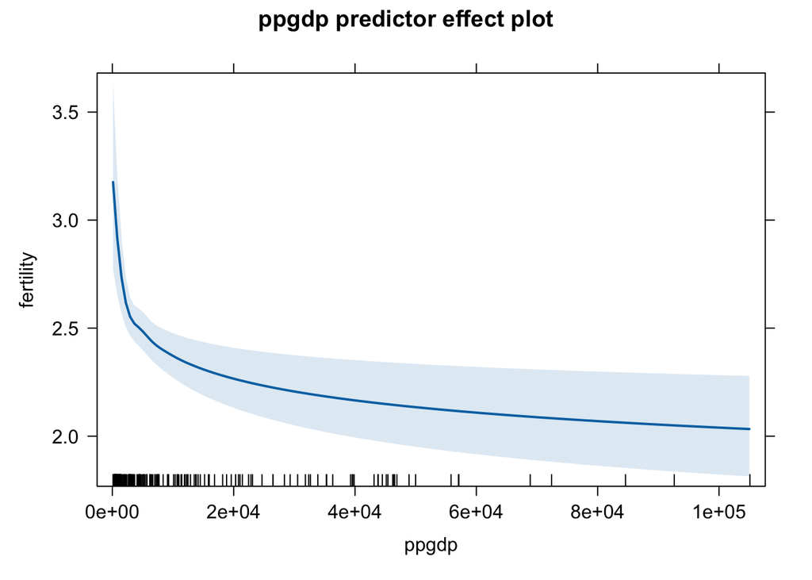

```r
plot(predictorEffect("ppgdp", lmod2),
     axes=list(y=list(transform=exp, lab="fertility")))
```